# Part 3 - Condition number of a matrix - Splines & Polynomial Regression

2023-03-14

Notes are adapted from Yu Zhao’s DSC241 lab sessions at UCSD.

We are interested in the following linear model:
$$\begin{equation}
y = X\beta + \epsilon
\end{equation}$$

- We aim to find the coefficient estimate $\hat{\beta}$, and $\hat{\beta}$ is affect by $\epsilon$.
- The condition number of $X$ measures how much can a change in $\epsilon$ affect the solution $\hat{\beta}$.
- If a matrix is singular, then its condition number is infinite. A finite large condition number means that the matrix is close to being singular.
- A problem with a low condition number is said to be well-conditioned, while a problem with a high condition number is said to be ill-conditioned.

# How to find the Condition Number of a matrix?

condition number = max singular value / min singular value –> Use SVD to calculate singular values

```r
X = matrix(c(3.2,-7.6,2.2,-5.2),nrow = 2)
svd_X = svd(X)
k_X = max(svd_X$d)/min(svd_X$d)
k_X
```

```
## [1] 1248.499
```

Check the sensitivity of the solution to changes in $y$

```r
beta = matrix(c(1,2),nrow = 2)
y = X%*%beta
solve(X, y)
```

```
##      [,1]
## [1,]    1
## [2,]    2
```

```r
solve(X, y + rnorm(2,0,0.5))
```

```
##            [,1]
## [1,]   9.539595
## [2,] -10.498366
```

```r
solve(X, y + rnorm(2,0,0.5))
```

```
##           [,1]
## [1,]  11.40797
## [2,] -13.17606
```

```r
solve(X, y + c(0,0.1))
```

```
##       [,1]
## [1,] -1.75
## [2,]  6.00
```

As we can see, the solution changes dramatically even there is only a small change in $y$.

How about the polynomial regression?

```r
n = 100
p = 10
x = runif(100)
X = poly(x, degree = p, raw = TRUE)
X = cbind(rep(1, n), X) # get a complete desgin matrix, add a column of one
d = svd(X)$d  # svd outputs 3 matrices u v d --> we use d to extract the singular values

# d is a vector containing the singular values of x, of length min(n, p), sorted decreasingly.

max(d)/min(d) #condition number = max singular value / min singular value
```

```
## [1] 27406958
```

The condition number here is 2.7406958^{7}, which is very large, which means the model is not stable.

```r
n = 100
p = 2
x = runif(100)
X = poly(x, degree = p, raw = TRUE)
X = cbind(rep(1, n), X)
d = svd(X)$d
max(d)/min(d)
```

```
## [1] 27.18113
```

Here we check with smaller $p$ –> more stable, smaller cond number How small is small cond number? –> We can treat $p$ as a tuning parameter

# Why is the condition number important?

Wikipedia: In numerical analysis, the condition number of a function measures how much the output value of the function can change for a small change in the input argument. This is used to measure how sensitive a function is to changes or errors in the input, and how much error in the output results from an error in the input.

# How to tune $p$? Given that changing $p$ also changes the stability of the model.

We can use Hypothesis testing and anova to compare different model, each time we increase p, we add a column!

```r
load("datasets/04cars.rda")
tmp = dat[,c(13,15,16,18,19)]
tmp = tmp[complete.cases(tmp),]
tmp = as.data.frame(tmp)
names(tmp) = c("hp", "mpg", "wt", "len", "wd")
dat = tmp
attach(dat)
fit1 <- lm(mpg ~ wt + len + wd + hp,data = dat)
fit2 <- lm(mpg ~ wt + len + wd + poly(hp, 2, raw = TRUE))
fit3 <- lm(mpg ~ wt + len + wd + poly(hp, 3, raw = TRUE))
fit4 <- lm(mpg ~ wt + len + wd + poly(hp, 4, raw = TRUE))
fit5 <- lm(mpg ~ wt + len + wd + poly(hp, 5, raw = TRUE))
fit6 <- lm(mpg ~ wt + len + wd + poly(hp, 6, raw = TRUE))
fit7 <- lm(mpg ~ wt + len + wd + poly(hp, 7, raw = TRUE))
anova(fit1,fit2,fit3,fit4,fit5,fit6,fit7)
```

```
## Analysis of Variance Table
##
## Model 1: mpg ~ wt + len + wd + hp
## Model 2: mpg ~ wt + len + wd + poly(hp, 2, raw = TRUE)
## Model 3: mpg ~ wt + len + wd + poly(hp, 3, raw = TRUE)
## Model 4: mpg ~ wt + len + wd + poly(hp, 4, raw = TRUE)
## Model 5: mpg ~ wt + len + wd + poly(hp, 5, raw = TRUE)
## Model 6: mpg ~ wt + len + wd + poly(hp, 6, raw = TRUE)
## Model 7: mpg ~ wt + len + wd + poly(hp, 7, raw = TRUE)
##   Res.Df    RSS Df Sum of Sq       F    Pr(>F)
## 1    382 3860.7
## 2    381 3527.6  1    333.08 50.4702 6.103e-12 ***
## 3    380 3100.6  1    427.08 64.7132 1.143e-14 ***
## 4    379 2714.1  1    386.47 58.5595 1.676e-13 ***
## 5    378 2557.3  1    156.74 23.7503 1.620e-06 ***
## 6    377 2504.3  1     52.99  8.0299  0.004849 **
## 7    376 2481.5  1     22.88  3.4667  0.063396 .
## ---
## Signif. codes:  0 '***' 0.001 '**' 0.01 '*' 0.05 '.' 0.1 ' ' 1
```

As we can see here, p values are all small (p < 0.05) until we go from model 6 to model 7. So we might want to stop at the model 6.

How to interpret Pr(>F) in F test?

m1: $y = x + \epsilon$ m2: $y = x + x^2 + \epsilon$

–> F test p is small, reject null hypo (null hypo: adding column is not helpful) –> add one column is useful

# What is Splines and how to use Splines?

Consider data on a set of 892 females under 50 years collected in three villages in West Africa. We would like to explore the relationship between age (in years) and a crude measure of body fat, which is triceps skinfold thickness.

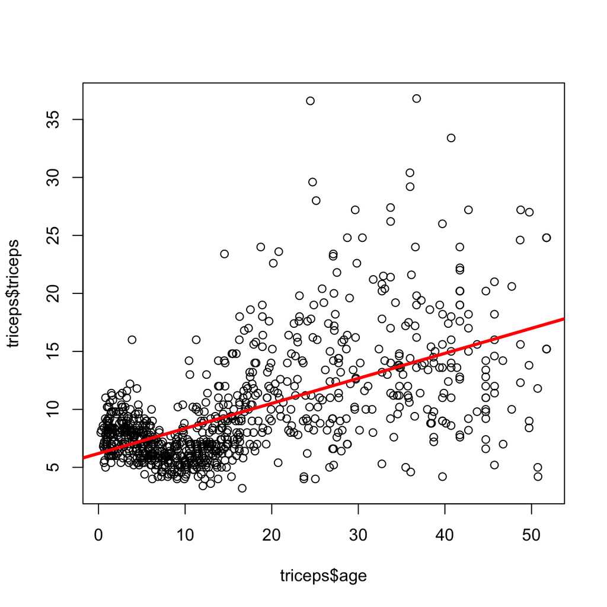

```r
triceps <- read.csv('datasets/triceps.csv')
plot(triceps$triceps~triceps$age)
abline(lm(triceps~age,data = triceps),col = 'red',lwd = 3)
```

First try polynomial fit:

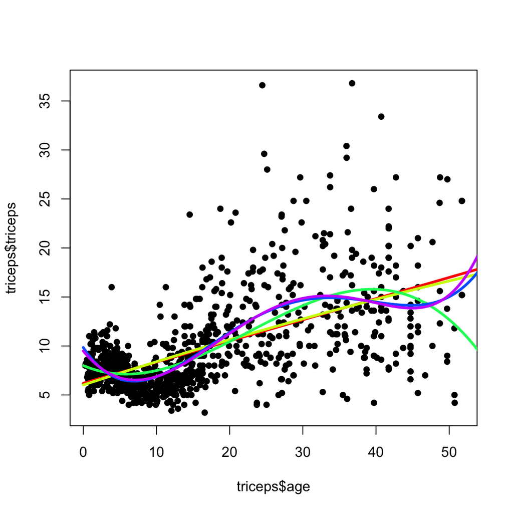

```r
pts = seq(0,55,by = 0.1)
plot(triceps$age, triceps$triceps, pch = 16)
for (d in 1:5){
    fit = lm(triceps ~ poly(age, d, raw = TRUE),data = triceps)
    val = predict(fit, data.frame(age = pts))
    lines(pts, val, col=rainbow(5)[d], lwd = 3)
    }
```

# What is Spline? Spline Regression is one of the non-parametric regression technique. In this technique the dataset is divided into bins at intervals or points which we called as knots. Also this bin has its separate fit.

# How to do Spline?

Spline of degree 2:

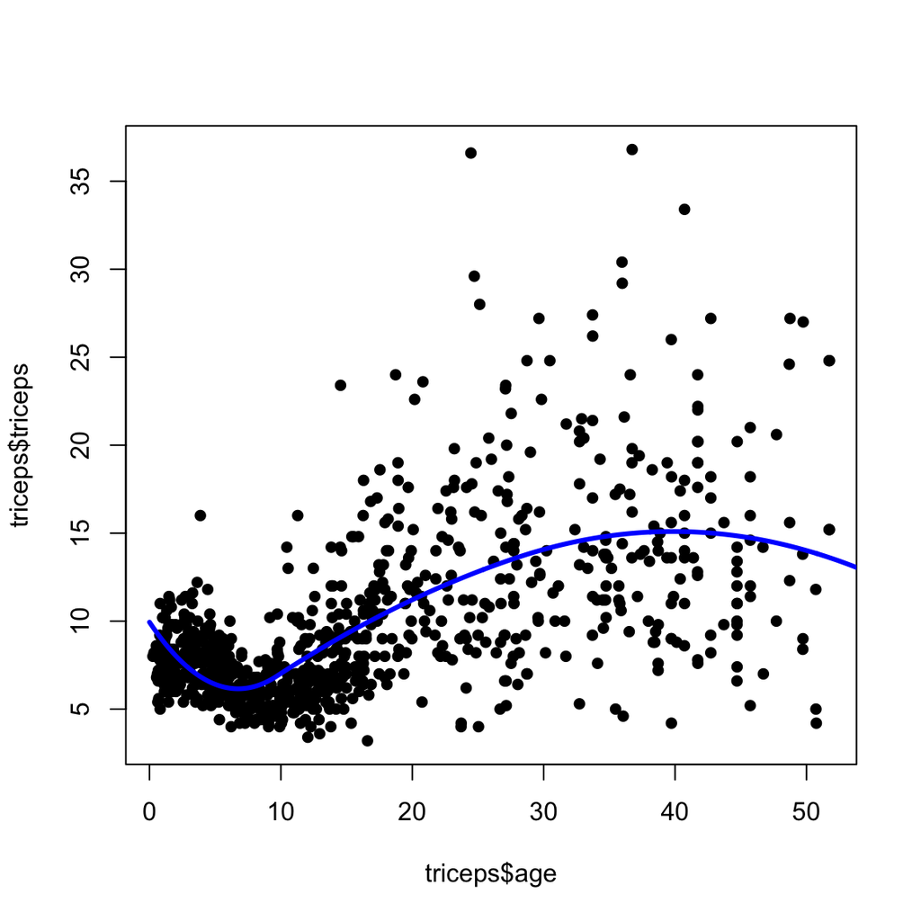

```r
K = quantile(triceps$age, c(0.4,0.8), type=1)
plot(triceps$age, triceps$triceps, pch = 16)
fit = lm(triceps ~ bs(age,degree=2,knots=K),data = triceps)
val = predict(fit, data.frame(age = pts))
lines(pts, val, col="blue", lwd = 3)
```

Spline of degree 3:

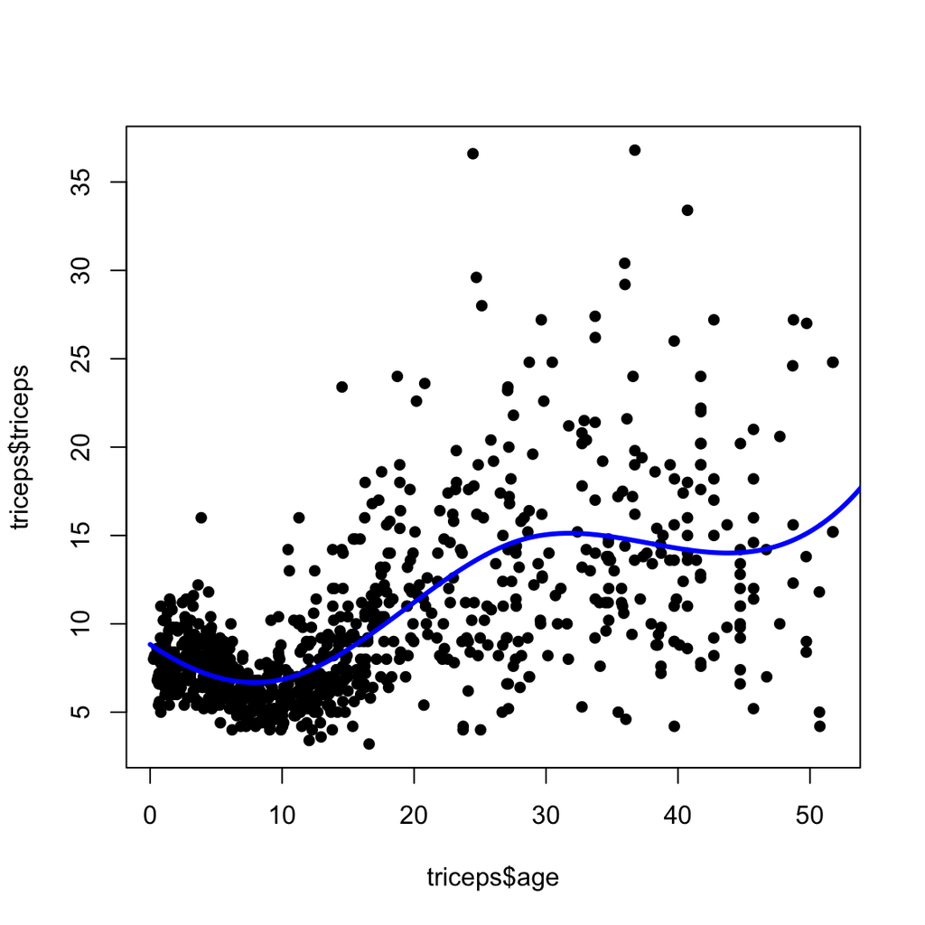

```r
K = quantile(triceps$age, c(0.4,0.8), type=1)
plot(triceps$age, triceps$triceps, pch = 16)
fit = lm(triceps ~ bs(age,degree=3,knots=K),data = triceps)
val = predict(fit, data.frame(age = pts))
lines(pts, val, col="blue", lwd = 3)
```

Spline of degree 4:

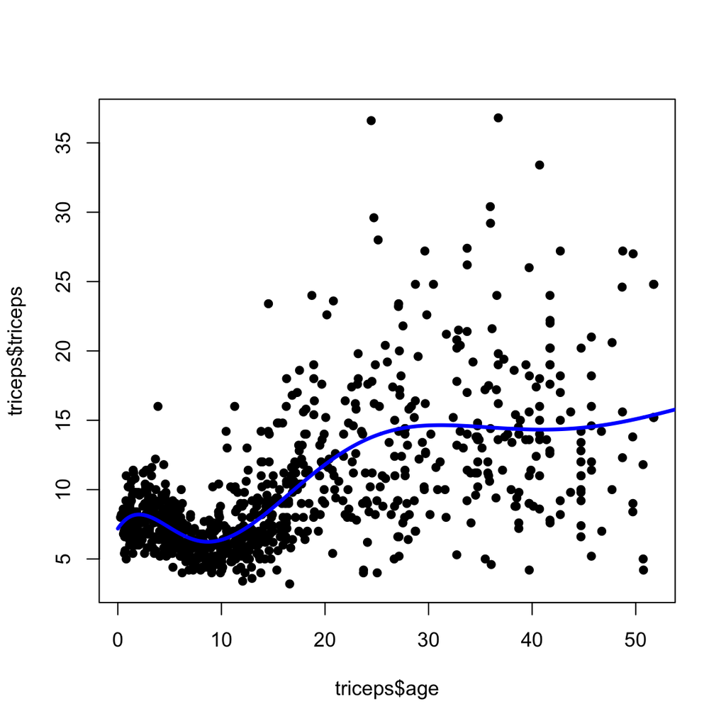

```r
K = quantile(triceps$age, c(0.4,0.8), type=1)
plot(triceps$age, triceps$triceps, pch = 16)
fit = lm(triceps ~ bs(age,degree=4,knots=K),data = triceps)
val = predict(fit, data.frame(age = pts))
lines(pts, val, col="blue", lwd = 3)
```